# Control y Descontrol

SUS 2211 — Mapeando la (in)sustentabilidad

Felipe Jordán

2026-04-06

## Plan para hoy

### Primer bloque

- A+R: La vigencia de Rachel Carson
- CT: Control y Descontrol

### Segundo bloque

- CT: La Gran Transición
- Presentación Tarea 05

# A+R: La Vigencia de Rachel Carson

## Reflexión en parejas

*Silent Spring* fue publicado hace más de 60 años…

1. ¿Sigue vigente el mensaje principal de los capítulos leídos?
2. ¿Qué contaminantes crees que han permeado los ecosistemas en Chile?
3. ¿Qué amenazas contemporáneas conoces que sean comparables al DDT?

## La carta de la IA

Lean el resumen del siguiente artículo, escrito por los propios creadores de la IA — incluidos dos premios Turing — alertando sobre los riesgos de la tecnología que ellos mismos construyeron:

Gestionar los riesgos extremos de la IA — resumen en español

¿Cómo relacionan el artículo con la lectura de Carson?

Carson advertía sobre tecnologías adoptadas sin comprender sus consecuencias. Los creadores del DDT nunca publicaron esa advertencia — los de la IA sí. ¿Será suficiente?

## Plenario

Algunas parejas comparten sus reflexiones.

- ¿Qué paralelos encontraron entre Carson y la carta sobre IA?
- ¿Qué contaminantes mencionaron para el caso chileno?

# CT: Control y Descontrol

## El poder de la ciencia moderna

Los avances de la ciencia y la tecnología nos han puesto en una posición única: somos la primera especie que tiene un **control consciente** del bioma

Este tremendo poder ha sido utilizado para el beneficio de la humanidad, pero también contra ella

En muchas ocasiones hemos adoptado los avances sin detenernos a reflexionar en las consecuencias: **efectos no deseados**

Revisaremos 6 tecnologías que ilustran este patrón

## Seis tecnologías, un patrón

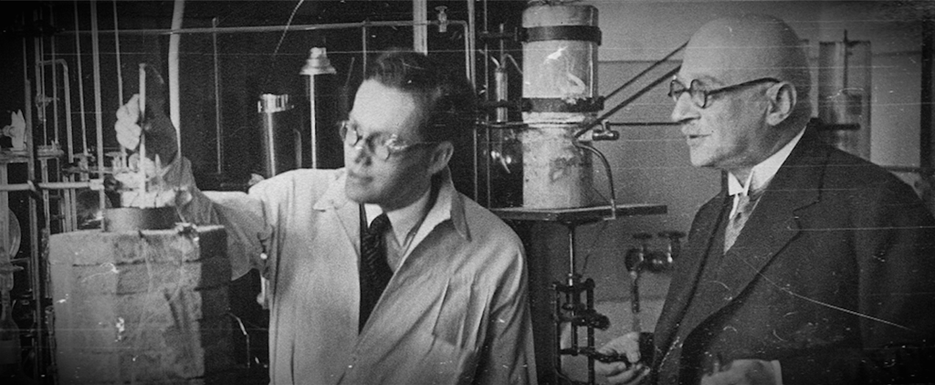

Método Haber-Bosch

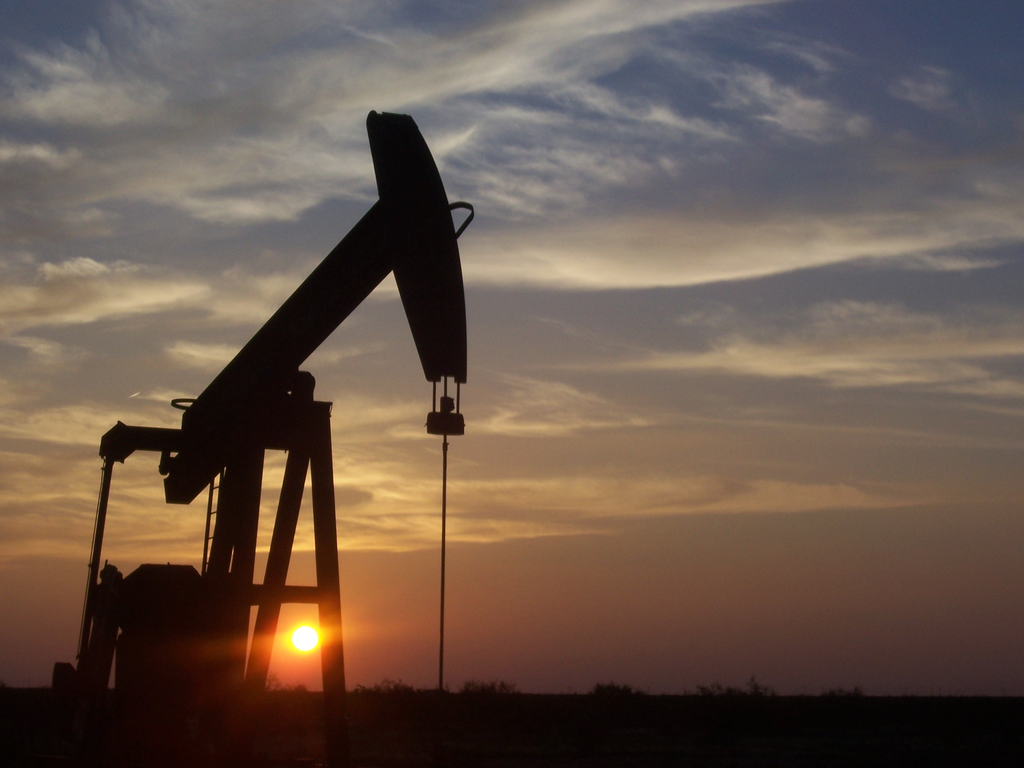

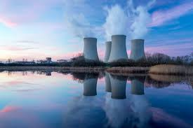

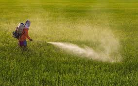

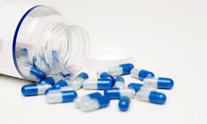

Antibióticos

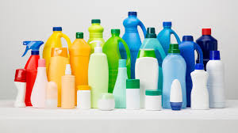

Plástico

## Método Haber-Bosch: lo bueno

**Lo bueno**

El método Haber-Bosch revolucionó la agricultura. Extrae el nitrógeno — un nutriente esencial para el crecimiento vegetal — del aire (78% N₂)

Así, Haber y Bosch lograron hacer **“pan del aire”**

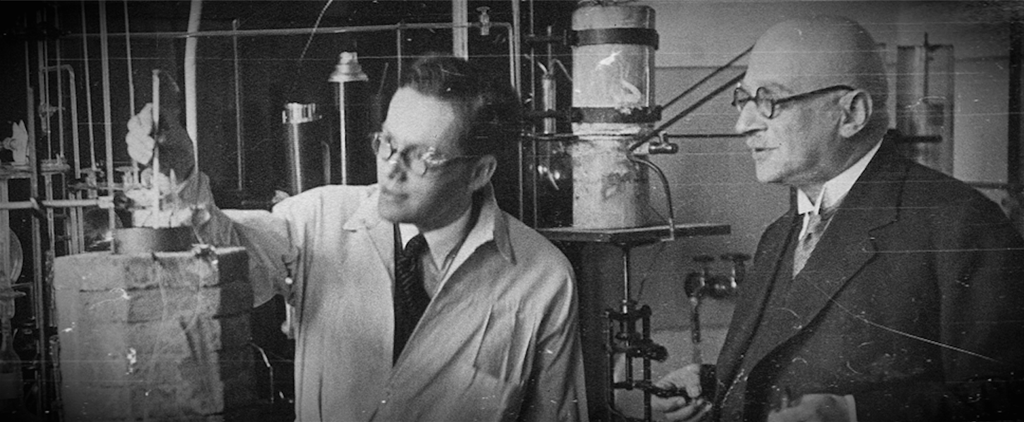

## Método Haber-Bosch: lo malo

**Lo malo**

El uso indiscriminado de fertilizantes ha desbalanceado el ciclo natural del nitrógeno

La abundancia excesiva de nutrientes lleva a la **eutrofización** de los cuerpos de agua — no solo matando la vida acuática, sino haciendo el agua tóxica para los humanos

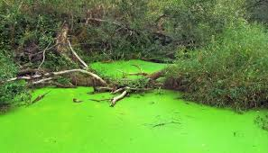

## Pesticidas: lo bueno

**Lo bueno**

Los pesticidas han permitido aumentar la productividad agrícola industrial

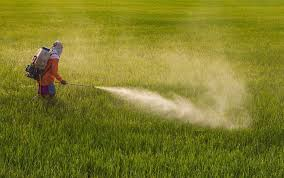

## Pesticidas: lo malo

**Lo malo**

El uso indiscriminado de pesticidas no solo mata a la peste objetivo, sino a muchos seres vivos que cumplen funciones claves en el ecosistema, como los **polinizadores**

Los pesticidas se acumulan en el ambiente. Se transmiten a través de la **cadena trófica**, eventualmente exponiendo a los humanos

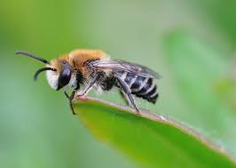

## Pesticidas: bioacumulación

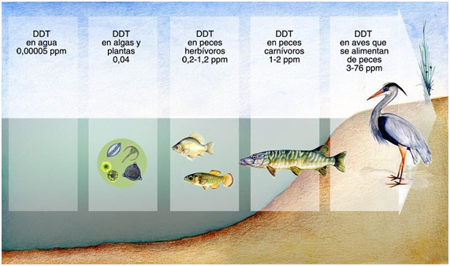

La bioacumulación de pesticidas en la cadena trófica — el fenómeno central que denunció Rachel Carson en *Silent Spring*.

## Combustibles fósiles: lo bueno

**Lo bueno**

Los combustibles fósiles han sido claves para el proceso de industrialización que ha sacado a millones de personas de la pobreza

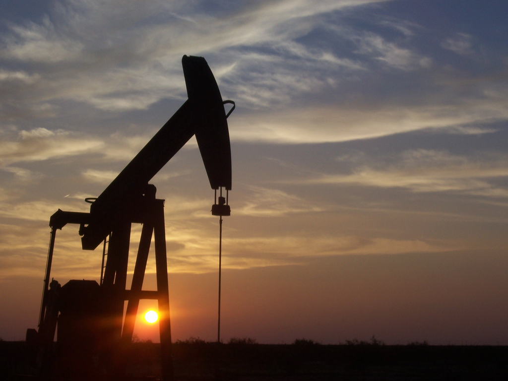

## Combustibles fósiles: lo malo

**Lo malo**

El CO₂ es el principal responsable del **cambio climático**

La contaminación atmosférica causa **7 millones de muertes prematuras** al año (OMS)

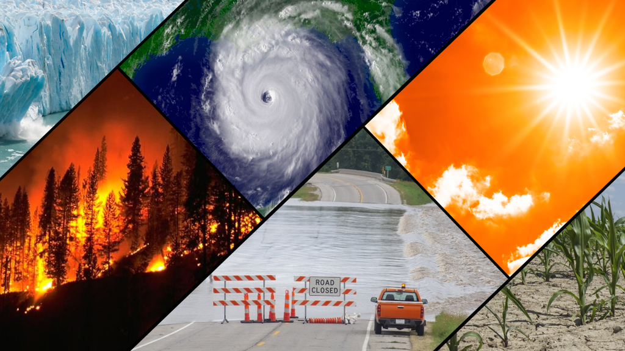

[figure not shown]

## Energía nuclear: lo bueno

**Lo bueno**

La energía atómica es extremadamente eficiente y no genera emisiones de CO₂

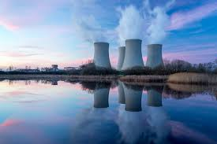

## Energía nuclear: lo malo

**Lo malo**

El desarrollo bélico de la energía atómica puso, por primera vez, la posibilidad de poner fin a la vida en la Tierra en manos de los seres humanos

Los desechos nucleares son difíciles de gestionar, y durante décadas se tiraron al mar

Los accidentes nucleares, si bien infrecuentes, pueden dejar el ambiente contaminado con radiación por siglos

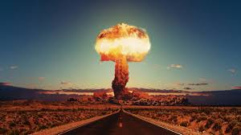

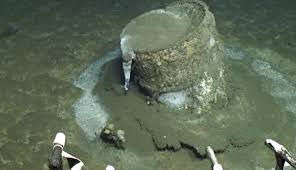

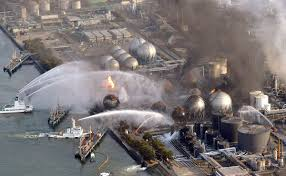

## Antibióticos: lo bueno

**Lo bueno**

El descubrimiento accidental de la penicilina por Alexander Fleming ha salvado millones de vidas

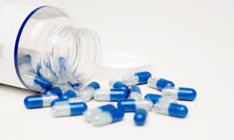

## Antibióticos: lo malo

**Lo malo**

El uso indiscriminado de los antibióticos ha llevado a una **“carrera armamentista”** contra las bacterias, que generan resistencia

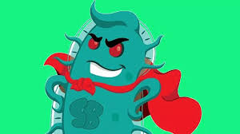

## Plástico: lo bueno

**Lo bueno**

El plástico es un material resistente pero flexible, y ha hecho posible gran parte de los bienes que usamos

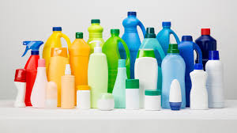

## Plástico: lo malo

**Lo malo**

La deposición irresponsable de plásticos contamina el ambiente, afectando gravemente a la fauna

Al degradarse, el plástico se convierte en **microplástico**, el cual se acumula en la cadena trófica

El documental [*Albatross*](https://www.albatrossthefilm.com/) muestra el impacto devastador del plástico en las aves marinas de Midway Atoll

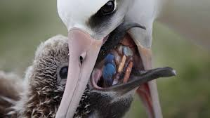

## Plástico: la contaminación invisible

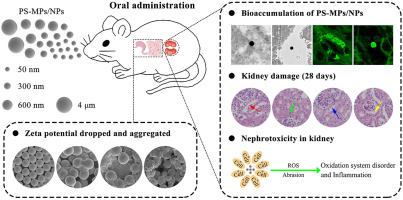

Los microplásticos se han encontrado en la sangre humana, la placenta, la leche materna y hasta en la nieve de la Antártica.

## Reflexión: ¿otros ejemplos?

¿Saben de otros ejemplos de progresos de la modernidad que han tenido consecuencias negativas no anticipadas?

## Síntesis: “the solution to pollution is NOT dilution”

Durante mucho tiempo, se creía que *“the solution to pollution is dilution”*

Sin embargo, podemos decir que *“it is a **delusion** that the solution to pollution is dilution”*

El gran poder que hemos ganado con la ciencia trae consigo una **gran responsabilidad**

Esto no nos debe llevar a paralizar el progreso, pero sí a avanzar con **precaución** — el **principio precautorio**

# CT: La Gran Transición

## Energía como “baterías”

La fuente de energía que nos sustenta desde tiempos inmemoriales proviene del flujo de radiación que recibimos del sol

Podemos pensar en las fuentes de energía que utilizamos como **“baterías”**, que se cargan con el sol en un stock disponible para nuestro consumo

[figure not shown]

## Las baterías del sol

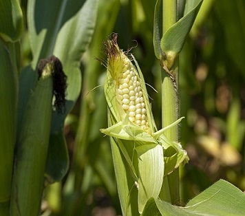

**Cultivos:** se “cargan” en menos de 1 año

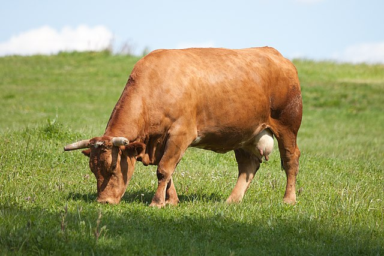

**Ganado:** se “carga” en 2–3 años

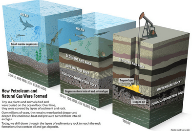

**Combustibles fósiles:** se “cargan” en millones de años

## La descarga rápida de la batería terrestre

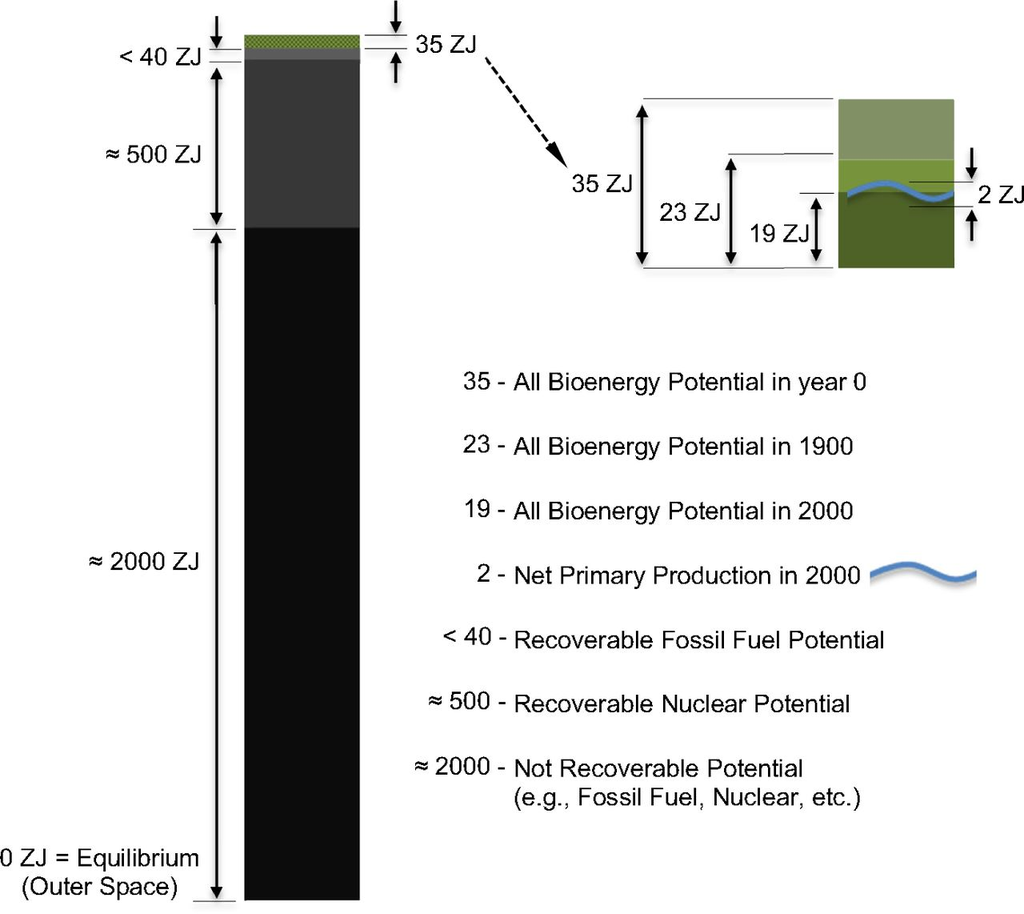

La explosión del uso de combustibles fósiles implica que estamos **descargando la batería** a una velocidad sin precedente

Fuente: Schramski, J., Gattie, D. & Brown, J. (2015). Human domination of the biosphere: Rapid discharge of the earth-space battery foretells the future of humankind. *PNAS*, 112(31): 9511–9517.

## La batería se está agotando

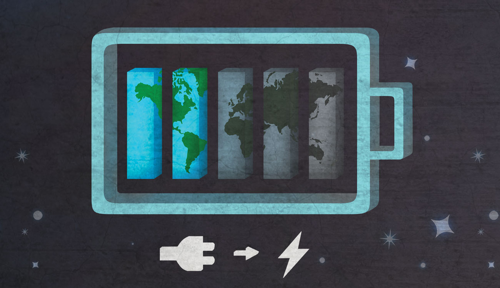

Fuente: University of Georgia Research — “Earth’s battery is running low.”

## Dos razones para la transición

**Razón 1: Agotamiento**

En ausencia del cambio climático, la rápida descarga implicaría que sería importante explorar alternativas para sostenernos con energías renovables, dado que eventualmente las energías fósiles se terminarán

**Razón 2: Urgencia climática**

La forma en que usamos la energía (quemándola) ha aumentado la concentración de CO₂ y está cambiando el clima, lo que potencialmente traerá efectos catastróficos si no actuamos ahora

Ante este escenario, se hace **urgente** comenzar la Gran Transición

## CO₂ por sector: la energía domina

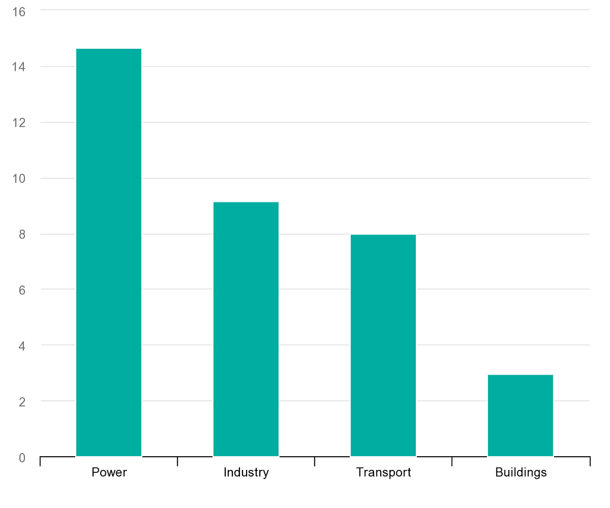

Emisiones de CO₂ (Gt) en 2022. Fuente: IEA.

- Por lejos el sector que más emisiones genera es el de la **energía**
- La electrificación de los otros sectores solo disminuirá las emisiones en la medida que la producción de energía se **descarbonize**

## Chile: el boom de las ERNC

[figure not shown]

[figure not shown]